# Project Arbitrage Stragegy

**Summary and Introduction:**

In this report, we delve into the development and implementation of an arbitrage trading strategy in the spot market. Arbitrage, a cornerstone of financial markets, involves exploiting price differentials of the same asset across different markets or exchanges to secure risk-free profits. Our goal is to design a trading strategy leveraging data from two exchanges over a three-day period to identify and capitalize on such arbitrage opportunities.

**Introduction:**

Arbitrage, a fundamental concept in financial markets, presents traders with the opportunity to profit from price discrepancies of identical assets across different platforms. In this report, we explore the application of arbitrage trading strategies in the context of the spot market, focusing on two exchanges trading the same instrument over a three-day period. Our strategy aims to detect instances where the price of the same asset diverges between exchanges, allowing us to execute trades that lock in guaranteed profits. Through careful analysis of market data and the implementation of trading algorithms, we seek to develop a robust approach that maximizes profit potential while managing risks associated with execution latency and transaction fees.

```python
import pandas as pd
import os
import numpy as np
import matplotlib.pyplot as plt
```

1. The `directory` variable holds the file path pointing to the directory containing the CSV files, facilitating easy access to the data needed for analysis and trading strategy development.

```python
# Path to the directory containing the CSV files
directory = "C:\\Users\\khafif\\Desktop\\Data defi trader\\"
```

1. The `files` list stores the names of the CSV files corresponding to the order book data from two exchanges over a three-day period, enabling efficient iteration and processing of the data to identify arbitrage opportunities.

```python
# List of exchange files
files = ["exchange1_20210519", "exchange1_20210520", "exchange1_20210521",
         "exchange2_20210519", "exchange2_20210520", "exchange2_20210521"]
```

```python
# Initialize lists to store tracking data
timestamps = []
profits = []
```

## Introduction to the strategy

### Significance

This holistic approach, considering both prices and quantities, allows for a more precise and realistic identification of arbitrage opportunities in cryptocurrency markets. However, it does not consider execution time, hence leading to a statistical arbitrage opportunity. It accounts for transaction fees and quantity availability to maximize potential profit while remaining realistic about transaction execution.

# Statistical Arbitrage Strategy

## Introduction

In the dynamic landscape of financial markets, traders are constantly seeking opportunities to capitalize on price inefficiencies across different assets or exchanges. One approach to identifying such opportunities is through statistical arbitrage, which involves exploiting temporary mispricing of assets based on quantitative analysis.

### Correlation Analysis

Correlation analysis plays a pivotal role in statistical arbitrage strategies by examining the relationship between the prices of two or more assets or exchanges. A high correlation coefficient suggests that the prices move in tandem, while a low correlation indicates divergence in price movements.

Traders leverage correlation analysis to identify pairs of assets or exchanges with historically high correlation coefficients. By monitoring these pairs, traders can anticipate when price movements may deviate from their historical relationship, potentially signaling an arbitrage opportunity. For instance, if two exchanges typically exhibit high correlation but suddenly diverge in price, traders may exploit this discrepancy by simultaneously buying on the lower-priced exchange and selling on the higher-priced exchange.

### Beta Coefficient

Beta coefficient, a measure of systematic risk or volatility, complements correlation analysis in assessing the relationship between an asset and a benchmark index, such as the overall market. In the context of statistical arbitrage, beta coefficient helps traders gauge the sensitivity of an asset's returns to broader market movements.

Traders utilize beta coefficient to construct pairs of assets with similar market exposures but potentially different price movements. By pairing assets with similar betas, traders aim to neutralize market risk and isolate idiosyncratic price movements, which could present arbitrage opportunities. For example, if two assets have similar betas but temporarily diverge in price, traders may exploit this mispricing by taking opposing positions in the assets, anticipating a convergence in their prices over time.

### Exploiting Arbitrage Opportunities

By combining correlation analysis and beta coefficient assessment, traders can systematically identify and exploit statistical arbitrage opportunities. High correlation coupled with divergent price movements or similar betas with temporary mispricing may signal potential arbitrage opportunities. Traders can capitalize on these opportunities by executing simultaneous buy and sell orders across the mispriced assets or exchanges, aiming to profit from the eventual price convergence.

### Correlation Analysis

```python
import numpy as np

def calculate_correlation(prices1, prices2):
    # Si l'un des arguments est un flottant, retourner directement ce flottant
    if isinstance(prices1, (int, float)) or isinstance(prices2, (int, float)):
        return prices1 * prices2  # C'est un exemple, vous pouvez définir le calcul souhaité

    # Sinon, calculer la corrélation entre les tableaux numpy
    if isinstance(prices1, np.ndarray) and isinstance(prices2, np.ndarray):
        correlation_coefficient = np.corrcoef(prices1, prices2)[0, 1]
        return correlation_coefficient
    else:
        raise ValueError("Both inputs must be numpy arrays or scalars.")
```

```python
# Initialiser des listes pour stocker les prix d'achat et de vente pour chaque échange
exchange1_buy_prices_all = []
exchange1_sell_prices_all = []
exchange2_buy_prices_all = []
exchange2_sell_prices_all = []

# Boucler à travers chaque fichier
# Seulement les deux premiers jours comme mentionné dans l'annonce
for file in files[:2]:
    # Extraire le nom de l'échange et la date à partir du nom du fichier
    exchange_name, date = file.split("_")

    # Créer les chemins des fichiers CSV
    exchange1_file = os.path.join(directory, f"{file}.csv")
    exchange2_file = os.path.join(directory, f"{exchange_name}_{date}.csv")

    # Lire les fichiers CSV dans les DataFrames
    exchange1_data = pd.read_csv(exchange1_file, header=None)
    exchange2_data = pd.read_csv(exchange2_file, header=None)

    # Échantillonner les données toutes les 10 lignes pour accélérer le traitement
    exchange1_data = exchange1_data.iloc[::10]
    exchange2_data = exchange2_data.iloc[::10]

    # Extraire les prix d'achat et de vente pour chaque échange et les ajouter aux listes agrégées
    exchange1_buy_prices_all.extend(exchange1_data.iloc[:, 3:13:2].values.flatten())
    exchange1_sell_prices_all.extend(exchange1_data.iloc[:, 4:14:2].values.flatten())
    exchange2_buy_prices_all.extend(exchange2_data.iloc[:, 3:13:2].values.flatten())
    exchange2_sell_prices_all.extend(exchange2_data.iloc[:, 4:14:2].values.flatten())

# Convertir les listes de prix en tableaux NumPy
exchange1_buy_prices_all = np.array(exchange1_buy_prices_all)
exchange1_sell_prices_all = np.array(exchange1_sell_prices_all)
exchange2_buy_prices_all = np.array(exchange2_buy_prices_all)
exchange2_sell_prices_all = np.array(exchange2_sell_prices_all)

# Calculer la corrélation entre les prix des deux échanges à partir des données agrégées
correlation = calculate_correlation(np.concatenate((exchange1_buy_prices_all, exchange1_sell_prices_all)),
                                    np.concatenate((exchange2_buy_prices_all, exchange2_sell_prices_all)))

# Afficher la corrélation globale entre les prix des deux échanges
print(f"Global Correlation between Exchange 1 and Exchange 2: {correlation}")
```

```
Global Correlation between Exchange 1 and Exchange 2: 1.0
```

### Beta Coefficient

```python
import numpy as np

# Calculer les rendements pour chaque échange
exchange1_returns = (np.array(exchange1_sell_prices_all) - np.array(exchange1_buy_prices_all)) / np.array(exchange1_buy_prices_all)
exchange2_returns = (np.array(exchange2_sell_prices_all) - np.array(exchange2_buy_prices_all)) / np.array(exchange2_buy_prices_all)

# Calculer la covariance entre les rendements des deux échanges
covariance = np.cov(exchange1_returns, exchange2_returns)[0, 1]

# Calculer la variance des rendements de l'échange 2
variance_exchange2_returns = np.var(exchange2_returns)

# Calculer le coefficient bêta
beta = covariance / variance_exchange2_returns

# Afficher le coefficient bêta
print(f"Beta: {beta}")
```

```
Beta: 1.000000442096613
```

## Conclusion

However, it's important to note that despite these findings, trading based on this correlation and beta coefficient requires further analysis of transaction costs, market risks, and other external factors that may influence prices. Additionally, financial markets being subject to rapid changes, it's essential to closely monitor market conditions and adjust the strategy accordingly.

## Explanation of calculate_arbitrage_profit Function

The `calculate_arbitrage_profit` function is designed to determine the potential profit from arbitrage trading between two exchanges based on price differentials and quantities of a particular asset pair. Below is a breakdown of the function's logic:

1. **Price Change Calculation**:
   - The function calculates the change in prices between time t and t+1 for both Exchange 1 and Exchange 2. This is done by subtracting the prices at time t from the prices at time t+1 for both exchanges.
2. **Arbitrage Opportunity Identification**:
   - It checks whether there is a positive price change on Exchange 1 and a negative price change on Exchange 2. This condition indicates a potential arbitrage opportunity, where one can buy on Exchange 1 and sell on Exchange 2 to profit from the price difference.
3. **Effective Quantity Determination**:
   - The effective quantity for this arbitrage opportunity is determined as the minimum of the quantities available for buying on Exchange 1 and selling on Exchange 2. This ensures that the arbitrage can be executed using the smallest available quantity across both exchanges.
4. **Profit Calculation**:
   - For each arbitrage opportunity identified, the function calculates the profit by subtracting the buying cost on Exchange 1 (including fees) from the selling revenue on Exchange 2 (excluding fees), considering the effective quantity traded.
5. **Total Net Profit Calculation**:
   - Finally, the function sums up all the profits obtained from different arbitrage opportunities to calculate the total net profit.

This function provides a systematic approach to evaluate potential arbitrage opportunities between two exchanges, considering both price differentials and transaction quantities, which are essential factors in arbitrage trading strategies.

```python
def calculate_arbitrage_profit(price_buy_exchange1_t, quantity_buy_exchange1_t,
                               price_buy_exchange1_t_plus_1, quantity_buy_exchange1_t_plus_1,
                               price_sell_exchange2_t, quantity_sell_exchange2_t,
                               price_sell_exchange2_t_plus_1, quantity_sell_exchange2_t_plus_1,
                               fee_rate):
    net_profit = 0

    # Calculate the change in prices between t and t+1 for exchange 1 and exchange 2
    price_change_exchange1 = price_buy_exchange1_t_plus_1 - price_buy_exchange1_t
    price_change_exchange2 = price_sell_exchange2_t_plus_1 - price_sell_exchange2_t

    # Check if there is a positive price change on exchange 1 and a negative price change on exchange 2
    positive_price_change_exchange1 = price_change_exchange1 > 0
    negative_price_change_exchange2 = price_change_exchange2 < 0

    # Determine the effective quantity for this opportunity
    effective_quantity = np.minimum(quantity_buy_exchange1_t, quantity_sell_exchange2_t)

    # Check if there is an arbitrage opportunity
    arbitrage_opportunity = positive_price_change_exchange1 & negative_price_change_exchange2

    # Calculate the profit for each arbitrage opportunity
    profit = np.where(arbitrage_opportunity,
                      (price_sell_exchange2_t * effective_quantity * (1 - fee_rate)) -
                      (price_buy_exchange1_t * effective_quantity * (1 + fee_rate)),
                      0)

    # Sum up all profits
    net_profit = np.sum(profit)

    return net_profit
```

```python
# Initialize a list to store profits for each minute
profits = []

# Iterate over the rows of the dataframes
for index, row in exchange1_data.iterrows():
    # Extract relevant data for the transaction at time t
    prices_exchange1_buy_t = row.iloc[3::2].values  # BID_PRICE_i columns at time t
    quantities_exchange1_buy_t = row.iloc[4::2].values  # BID_QTY_i columns at time t

    # Extract relevant data for the transaction at time t+1
    if index < len(exchange1_data) - 1:
        next_row = exchange1_data.iloc[index + 1]  # Get the next row
        prices_exchange1_buy_t_plus_1 = next_row.iloc[3::2].values  # BID_PRICE_i columns at time t+1
        quantities_exchange1_buy_t_plus_1 = next_row.iloc[4::2].values  # BID_QTY_i columns at time t+1

        # Extract corresponding data for exchange 2 at time t and t+1
        prices_exchange2_sell_t = exchange2_data.iloc[index, 3::2].values  # ASK_PRICE_i columns at time t
        quantities_exchange2_sell_t = exchange2_data.iloc[index, 4::2].values  # ASK_QTY_i columns at time t

        prices_exchange2_sell_t_plus_1 = exchange2_data.iloc[index + 1, 3::2].values  # ASK_PRICE_i columns at time t+1
        quantities_exchange2_sell_t_plus_1 = exchange2_data.iloc[index + 1, 4::2].values  # ASK_QTY_i columns at time t+1

        # Assume a fixed fee rate
        fee_rate = 0.0001  # 1 basis point

        # Calculate net profit after fees for the arbitrage opportunity between t and t+1
        profit = calculate_arbitrage_profit(prices_exchange1_buy_t, quantities_exchange1_buy_t,
                                             prices_exchange1_buy_t_plus_1, quantities_exchange1_buy_t_plus_1,
                                             prices_exchange2_sell_t, quantities_exchange2_sell_t,
                                             prices_exchange2_sell_t_plus_1, quantities_exchange2_sell_t_plus_1,
                                             fee_rate)

        # Add the profit to the list
        profits.append(profit)

        # Print arbitrage opportunities
        #if profit > 0:
         #   print(f"Opportunity to buy on {exchange_name} and sell on the other exchange - Profit: {profit}")
       # elif profit < 0:
        #    print(f"Opportunity to buy on the other exchange and sell on {exchange_name} - Profit: {abs(profit)}")
        #else:
         #   pass
            #print("No arbitrage opportunity")
print("First few arbitrage opportunities:")
print(profits[:10])
```

```
First few arbitrage opportunities:
[0, 910.7642446100083, 564.3013517999848, 0, 78.54496641000267, 198.1227066700061, 264.57910981000606, 206.9393063600029, 0, 371.9351432000034]
```

# Histogram Plotting for Positive Profits

1. **Import Libraries**: The code begins by importing the necessary libraries, including NumPy for numerical computations and Matplotlib for plotting.
2. **Filtering Profits**: It filters out any negative or zero profits from the list of profits obtained from the arbitrage trading strategy.
3. **Define Profit Bins**: The code defines the bins for the histogram based on the filtered positive profits. Bins are defined with a width of 100 units, starting from 0 up to the maximum profit plus 100 units.
4. **Plotting Histogram**: Using Matplotlib, the code generates a histogram plot of the filtered positive profits. The plot is configured with a specific figure size, bin edges, labels for the x and y axes, a title describing the plot, and grid lines for better readability.
5. **Display Plot**: Finally, the histogram plot is displayed using `plt.show()`.

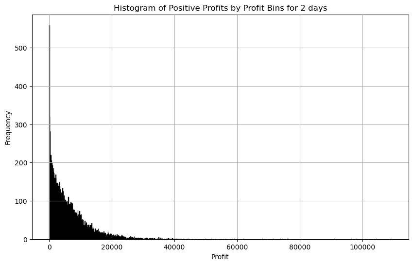

```python
import numpy as np
import matplotlib.pyplot as plt

# Filtrer les valeurs nulles et négatives de la liste des profits
filtered_profits = [profit for profit in profits if profit > 0]

# Définir les tranches de bénéfices
bins = np.arange(0, max(filtered_profits) + 100, 100)  # Par exemple, des tranches de 100

# Plotting de l'histogramme
plt.figure(figsize=(10, 6))
plt.hist(filtered_profits, bins=bins, edgecolor='black')
plt.xlabel('Profit')
plt.ylabel('Frequency')
plt.title('Histogram of Positive Profits by Profit Bins for 2 days')
plt.grid(True)
plt.show()
```

```python
# Calcul du profit global
total_profit = sum(filtered_profits)
print("Total Profit:", total_profit)
```

```
Total Profit: 93275693.84303984
```

## Conclusion and Limitations of the Arbitrage Trading Strategy

### Limitations

Despite its success, several limitations should be acknowledged:

1. **Data Quality**: The strategy heavily relies on the accuracy and timeliness of order book data. Any inaccuracies or delays in data transmission could lead to missed opportunities or erroneous trading decisions.
2. **Transaction Costs**: While the strategy considers trading fees, it may not fully account for other costs such as slippage, withdrawal fees, and exchange-specific fees, which can significantly impact overall profitability.
3. **Market Conditions**: Arbitrage opportunities may be fleeting and sensitive to market conditions, including liquidity, volatility, and macroeconomic factors. The strategy's effectiveness may vary under different market environments.
4. **Regulatory Risks**: Arbitrage trading strategies may face regulatory scrutiny, particularly in cases involving cross-border trading or compliance with specific exchange regulations.
5. **Execution Risks**: The strategy assumes instantaneous execution of trades upon order book updates, ignoring factors such as order fulfillment delays, network latency, and order queueing, which could affect the realized profit.
6. **Model Assumptions**: The strategy makes simplifying assumptions, such as fixed fee rates and uniform trade sizes, which may not accurately reflect real-world trading conditions. Additionally, the lack of consideration for correlation and beta may impact the strategy's efficiency, thus falling under statistical arbitrage.

### Future Directions

To address these limitations and enhance the robustness of the strategy, future research and development efforts could focus on:

- **Data Quality Enhancement**: Implementing data validation and cleansing techniques to improve the reliability of input data.
- **Cost Optimization**: Incorporating more comprehensive cost models to account for all relevant transaction costs and optimizing trade execution strategies to minimize costs.
- **Market Monitoring**: Implementing real-time market monitoring and adaptive trading algorithms to adapt to changing market conditions and seize fleeting opportunities.
- **Regulatory Compliance**: Ensuring compliance with relevant regulations and monitoring changes in the regulatory landscape to mitigate regulatory risks.
- **Risk Management**: Developing risk management frameworks to identify and mitigate execution risks, including position sizing, portfolio diversification, and risk hedging strategies.
- **Model Validation**: Conducting thorough backtesting and stress testing of the strategy under various market scenarios to validate its performance and robustness, taking into account correlation and beta.

By addressing these aspects, arbitrage trading strategies for the BTC-PERP pair in dollars can be refined and adapted to navigate the dynamic and complex landscape of financial markets effectively.

# Bonus

## Questions and Answers

1. **How is your approach affected by a change in position size, exchange fee, or latency?**
   - **Position Size:** A change in position size directly impacts the potential profit or loss of each trade. Larger positions amplify gains or losses but may also increase market impact and execution risk.
   - **Exchange Fee:** Higher exchange fees reduce the net profit per trade, making it more challenging to achieve profitability. Lower fees improve profit margins but may necessitate higher trading frequency to offset fixed costs.
   - **Latency:** Increased latency between order placement and execution diminishes the effectiveness of arbitrage strategies, as price differentials may erode before trades are executed.
2. **What are the highest/lowest limits that can be assumed for position size, exchange fee, and latency in order for your approach to work?**
   - **Position Size:** The approach can accommodate various position sizes, but excessively large positions may face liquidity constraints and market impact costs. Smaller positions may not yield significant profits.
   - **Exchange Fee:** The strategy remains viable with moderate exchange fees, typically below 1% per trade. However, excessively high fees may render the strategy unprofitable, especially for low-frequency trading.
   - **Latency:** Lower latency is preferable for arbitrage trading, with sub-millisecond speeds ideal for capturing fleeting price differentials. Latencies exceeding a few milliseconds may diminish profitability and increase execution risk.
3. **Are there any mechanisms to increase/decrease the trading frequency? What are the trade-offs of these changes?**
   - **Increase Trading Frequency:** Implementing algorithmic trading strategies with real-time monitoring and automated execution can increase trading frequency. However, higher frequency trading may exacerbate execution costs and market impact, necessitating advanced risk management techniques.
   - **Decrease Trading Frequency:** Adopting a more selective approach by filtering trades based on predefined criteria can reduce trading frequency. While this may mitigate execution costs, it may also lead to missed opportunities and lower overall profitability.
4. **How can we create a robust and reusable pipeline for research?**
   - Establish a modular and scalable architecture using object-oriented programming paradigms.
   - Implement data validation and error handling mechanisms to ensure pipeline reliability.
   - Document code thoroughly with comments and documentation strings for clarity and reproducibility.
   - Utilize version control systems such as Git to track changes and collaborate effectively.
5. **How can overfitting be prevented, so we can be confident that the strategy will perform well on live data?**
   - Employ rigorous backtesting procedures with out-of-sample data to validate strategy performance.
   - Implement robust risk management techniques to prevent overexposure to specific market conditions.
   - Regularly update and adapt the strategy based on new market information and evolving dynamics.
6. **What optimization techniques can we take advantage of to try to make the strategy better?**
   - Optimize trade execution algorithms to minimize slippage and transaction costs.
   - Utilize machine learning algorithms for pattern recognition and predictive modeling to enhance trading signals.
   - Implement advanced order types and routing strategies to access liquidity across multiple venues effectively.
7. **What are the best methods of interpreting and/or visualizing the results?**
   - Utilize interactive visualization tools such as Plotly or Bokeh for dynamic exploration of trading performance.
   - Generate performance metrics and visualizations, including equity curves, drawdown analysis, and Sharpe ratio calculations, to assess strategy effectiveness.
   - Conduct sensitivity analysis to understand the impact of key parameters on strategy performance and identify areas for improvement.